# Marginal Gain Per Check 2020 Employed

[Fan Wang](https://fanwangecon.github.io/)

2020-08-07

# 1 2020 V and C without Unemployment

This is the example vignette for function: [**snw_a4chk_wrk_bisec_vec**](https://github.com/FanWangEcon/PrjOptiSNW/tree/master/PrjOptiSNW/splanner/snw_a4chk_wrk_bisec_vec.m) from the [**PrjOptiSNW Package**](https://fanwangecon.github.io/PrjOptiSNW/)**.** This function solves for the V(states, check) for individuals working. Dense solution. Bisection, most time for the test here taken to genereate the income matrixes. But these can be generated out of the check loops.

## 1.1 Test SNW_A4CHK_WRK_BISEC_VEC Defaults Dense

Call the function with default parameters. Solve first for non-covid value and policy. Then depending on 2020 taxes, solve for 2020 policy and value.

```
mp_params = snw_mp_param('default_docdense');
% mp_params = snw_mp_param('default_dense');
mp_params('beta') = 0.95;
mp_controls = snw_mp_control('default_test');
mp_controls('bl_print_vfi') = false;
mp_controls('bl_timer') = true;
[V_ss,~,cons_ss,~] = snw_vfi_main_bisec_vec(mp_params, mp_controls);

Completed SNW_VFI_MAIN_BISEC_VEC;SNW_MP_PARAM=default_docdense;SNW_MP_CONTROL=default_test;time=501.6001
----------------------------------------
xxxxxxxxxxxxxxxxxxxxxxxxxxxxxxxxxxxxxxxx
CONTAINER NAME: mp_outcomes ND Array (Matrix etc)
xxxxxxxxxxxxxxxxxxxxxxxxxxxxxxxxxxxxxxxx
                i    idx    ndim     numel      rowN      colN           sum         mean       std      coefvari      min          max
                _    ___    ____    ________    ____    _________    ___________    _______    ______    ________    ________    __________

    V_VFI       1     1      6      4.37e+07     83     5.265e+05    -6.6619e+08    -15.245    21.865    -1.4343      -504.39    -0.0071775
    ap_VFI      2     2      6      4.37e+07     83     5.265e+05     1.3967e+09     31.962    36.426     1.1397            0        160.24
    cons_VFI    3     3      6      4.37e+07     83     5.265e+05     2.3276e+08     5.3263    8.4413     1.5848     0.036717        141.61

xxx TABLE:V_VFI xxxxxxxxxxxxxxxxxx
             c1         c2         c3         c4         c5        c526496      c526497      c526498      c526499      c526500
           _______    _______    _______    _______    _______    _________    _________    _________    _________    _________

    r1     -293.96    -293.57    -291.09    -285.44    -276.41      -4.3584      -4.2643      -4.1713      -4.0795      -3.9885
    r2     -284.42    -284.03    -281.55    -275.97    -267.24      -4.2519      -4.1612      -4.0717      -3.9832      -3.8955
    r3     -274.87    -274.48    -272.03    -266.62    -258.33      -4.1429      -4.0559      -3.9698      -3.8847      -3.8002
    r4     -265.22    -264.86    -262.58    -257.53    -249.74      -4.0309      -3.9475      -3.8649      -3.7833      -3.7017
    r5     -256.51    -256.17    -254.04     -249.3    -241.96      -3.9252      -3.8452      -3.7659      -3.6873      -3.6084
    r79    -13.642    -13.628    -13.535    -13.298    -12.896     -0.22092     -0.21058     -0.20086     -0.19173     -0.18315
    r80    -12.283    -12.269    -12.176    -11.939    -11.537     -0.16979     -0.16182      -0.1543     -0.14722     -0.14057
    r81    -10.605    -10.591    -10.498    -10.261    -9.8589     -0.11712     -0.11163     -0.10646     -0.10157     -0.09695
    r82    -8.3494    -8.3358    -8.2424    -8.0055    -7.6035    -0.065333    -0.062242     -0.05936    -0.056635    -0.054056
    r83    -5.0665    -5.0529    -4.9595    -4.7226    -4.3206    -0.020968    -0.019972    -0.019038    -0.018161    -0.017336

xxx TABLE:ap_VFI xxxxxxxxxxxxxxxxxx
           c1    c2        c3           c4           c5       c526496    c526497    c526498    c526499    c526500
           __    __    __________    _________    ________    _______    _______    _______    _______    _______

    r1     0     0     0.00051498    0.0066578    0.021589    112.13     117.67      123.4     129.31     135.72
```

[output cut: 100 more lines]

```
----------------------------------------
xxxxxxxxxxxxxxxxxxxxxxxxxxxxxxxxxxxxxxxx
CONTAINER NAME: mp_container_map ND Array (Matrix etc)
xxxxxxxxxxxxxxxxxxxxxxxxxxxxxxxxxxxxxxxx
                      i    idx    ndim     numel      rowN      colN           sum           mean          std        coefvari        min           max
                      _    ___    ____    ________    ____    _________    ___________    __________    __________    ________    ___________    __________

    C_W               1     1      6      4.37e+07     83     5.265e+05     2.3278e+08        5.3269        8.4414     1.5847        0.039761        141.62
    C_W_minus_C_ss    2     2      6      4.37e+07     83     5.265e+05          25096    0.00057428    0.00077346     1.3468     -5.0491e-08     0.0034451
    V_W               3     3      6      4.37e+07     83     5.265e+05    -6.6561e+08       -15.231        21.817    -1.4323         -499.24    -0.0071773
    V_W_minus_V_ss    4     4      6      4.37e+07     83     5.265e+05     5.8108e+05      0.013297      0.069536     5.2294      1.8604e-07        5.1503
    mn_MPC            5     5      6      4.37e+07     83     5.265e+05     7.2848e+06        0.1667       0.22452     1.3468     -1.4656e-05             1

mn_V_W_gain_check = V_W_2020 - V_emp_2020;
mn_MPC_W_gain_share_check = (C_W_2020 - cons_emp_2020)./(welf_checks*mp_params('TR'));
```

## 1.2 Dense Param Results Define Frames

Define the matrix dimensions names and dimension vector values. Policy and Value Functions share the same ND dimensional structure.

```
% Grids:
age_grid = 18:100;
agrid = mp_params('agrid')';
eta_H_grid = mp_params('eta_H_grid')';
eta_S_grid = mp_params('eta_S_grid')';
ar_st_eta_HS_grid = string(cellstr([num2str(eta_H_grid', 'hz=%3.2f;'), num2str(eta_S_grid', 'wz=%3.2f')]));
edu_grid = [0,1];
marry_grid = [0,1];
kids_grid = (1:1:mp_params('n_kidsgrid'))';
% NaN(n_jgrid,n_agrid,n_etagrid,n_educgrid,n_marriedgrid,n_kidsgrid);
cl_mp_datasetdesc = {};
cl_mp_datasetdesc{1} = containers.Map({'name', 'labval'}, {'age', age_grid});
cl_mp_datasetdesc{2} = containers.Map({'name', 'labval'}, {'savings', agrid});
cl_mp_datasetdesc{3} = containers.Map({'name', 'labval'}, {'eta', 1:length(eta_H_grid)});
cl_mp_datasetdesc{4} = containers.Map({'name', 'labval'}, {'edu', edu_grid});
cl_mp_datasetdesc{5} = containers.Map({'name', 'labval'}, {'marry', marry_grid});
cl_mp_datasetdesc{6} = containers.Map({'name', 'labval'}, {'kids', kids_grid});
```

## 1.3 Analyze Difference in V and C with Check

The difference between V and V with Check, marginal utility gain given the check.

```
% Generate some Data
mp_support_graph = containers.Map('KeyType', 'char', 'ValueType', 'any');
mp_support_graph('cl_st_xtitle') = {'Savings States, a'};
mp_support_graph('st_legend_loc') = 'eastoutside';
mp_support_graph('bl_graph_logy') = true; % do not log
mp_support_graph('it_legend_select') = 21; % how many shock legends to show
mp_support_graph('cl_colors') = 'jet';
```

MEAN(MN_V_GAIN_CHECK(A,Z))

Tabulate value and policies along savings and shocks:

```
% Set
ar_permute = [1,4,5,6,3,2];
% Value Function
st_title = ['MEAN(MN_V_W_GAIN_CHECK(A,Z)), welf_checks=' num2str(welf_checks) ', TR=' num2str(mp_params('TR'))];
tb_az_v = ff_summ_nd_array(st_title, mn_V_W_gain_check, true, ["mean"], 4, 1, cl_mp_datasetdesc, ar_permute);

xxx  MEAN(MN_V_W_GAIN_CHECK(A,Z)), welf_checks=2, TR=0.0017225  xxxxxxxxxxxxxxxxxxxxxxxxxxx
    group     savings      mean_eta_1    mean_eta_2    mean_eta_3    mean_eta_4    mean_eta_5    mean_eta_6    mean_eta_7    mean_eta_8    mean_eta_9    mean_eta_10    mean_eta_11    mean_eta_12    mean_eta_13    mean_eta_14    mean_eta_15    mean_eta_16    mean_eta_17    mean_eta_18    mean_eta_19 …
    _____    __________    __________    __________    __________    __________    __________    __________    __________    __________    __________    ___________    ___________    ___________    ___________    ___________    ___________    ___________    ___________    ___________    ___________ …

      1               0       0.94877       0.84952         0.761       0.68204       0.61169       0.54906       0.49336       0.44384       0.39983       0.36075        0.32605        0.29525        0.26793        0.24369         0.2222        0.20315        0.18627        0.17131        0.15807  …
      2      0.00051498       0.93806       0.84058       0.75354        0.6758       0.60645       0.54467       0.48966       0.44073       0.39722       0.35854        0.32418        0.29367        0.26658        0.24254        0.22122         0.2023        0.18554        0.17067        0.15751  …
      3       0.0041199       0.78107       0.71106        0.6451       0.58402       0.52829       0.47789       0.43252       0.39178       0.35525       0.32251        0.29319        0.26697        0.24352        0.22257        0.20386        0.18716        0.17227        0.15899        0.14716  …
      4        0.013905       0.59646       0.55133       0.50699       0.46454       0.42482       0.38817       0.35467       0.32416       0.29646       0.27135         0.2486        0.22803        0.20943        0.19264         0.1775        0.16385        0.15157        0.14053        0.13061  …
      5        0.032959       0.43075         0.404       0.37635        0.3489        0.3225       0.29766       0.27458       0.25327       0.23369       0.21574         0.1993        0.18427        0.17054        0.15802         0.1466        0.13622        0.12678        0.11822        0.11046  …
      6        0.064373         0.309       0.29293       0.27555       0.25773       0.24021       0.22343       0.20763        0.1929       0.17922       0.16658        0.15492        0.14419        0.13432        0.12525        0.11693         0.1093        0.10232       0.095923       0.090082  …

% Consumption
st_title = ['MEAN(MN_MPC_W_GAIN_CHECK(A,Z)), welf_checks=' num2str(welf_checks) ', TR=' num2str(mp_params('TR'))];
tb_az_c = ff_summ_nd_array(st_title, mn_MPC_W_gain_share_check, true, ["mean"], 4, 1, cl_mp_datasetdesc, ar_permute);

xxx  MEAN(MN_MPC_W_GAIN_CHECK(A,Z)), welf_checks=2, TR=0.0017225  xxxxxxxxxxxxxxxxxxxxxxxxxxx
    group     savings      mean_eta_1    mean_eta_2    mean_eta_3    mean_eta_4    mean_eta_5    mean_eta_6    mean_eta_7    mean_eta_8    mean_eta_9    mean_eta_10    mean_eta_11    mean_eta_12    mean_eta_13    mean_eta_14    mean_eta_15    mean_eta_16    mean_eta_17    mean_eta_18    mean_eta_19 …
    _____    __________    __________    __________    __________    __________    __________    __________    __________    __________    __________    ___________    ___________    ___________    ___________    ___________    ___________    ___________    ___________    ___________    ___________ …

      1               0     0.99793       0.99517       0.99272       0.99139       0.99133       0.99164       0.99198       0.99224       0.99244        0.99267        0.99305        0.99347        0.99387         0.9942        0.99433        0.99428        0.99415        0.99374        0.99226   …
      2      0.00051498     0.99755       0.99428       0.99139       0.98982       0.98974       0.99011       0.99051       0.99082       0.99107        0.99136        0.99183        0.99238        0.99294        0.99345        0.99371        0.99372        0.99359        0.99301        0.99136   …
      3       0.0041199     0.88288       0.87696       0.87559       0.87507       0.87497       0.87532       0.87609       0.87729       0.87911        0.88156        0.88441        0.88764        0.89134        0.89563        0.90028        0.90488        0.90905        0.91225         0.9146   …
      4        0.013905     0.79641       0.79399       0.79087       0.78961       0.78966       0.79044       0.79148       0.79245       0.79313        0.79338        0.79325        0.79273        0.79178        0.79045        0.78901         0.7878        0.78694        0.78591        0.78426   …
      5        0.032959     0.71442       0.70961       0.70732       0.70675       0.70741       0.70894       0.71095       0.71329       0.71565        0.71776        0.71954        0.72123        0.72266        0.72392        0.72484        0.72492        0.72406        0.72318        0.72187   …
      6        0.064373     0.64147       0.64074       0.64117       0.64223       0.64376        0.6456        0.6477       0.64988       0.65211        0.65449        0.65678        0.65907        0.66115        0.66337         0.6649        0.66623        0.66767        0.66855        0.66943   …
```

Graph Mean Values:

```
st_title = ['MEAN(MN\_V\_W\_GAIN\_CHECK(A,Z)), welf\_checks=' num2str(welf_checks) ', TR=' num2str(mp_params('TR')) ''];
mp_support_graph('cl_st_graph_title') = {st_title};
mp_support_graph('cl_st_ytitle') = {'MEAN(MN\_V\_W\_GAIN\_CHECK(a,z))'};
ff_graph_grid((tb_az_v{1:end, 3:end})', ar_st_eta_HS_grid, agrid, mp_support_graph);
```

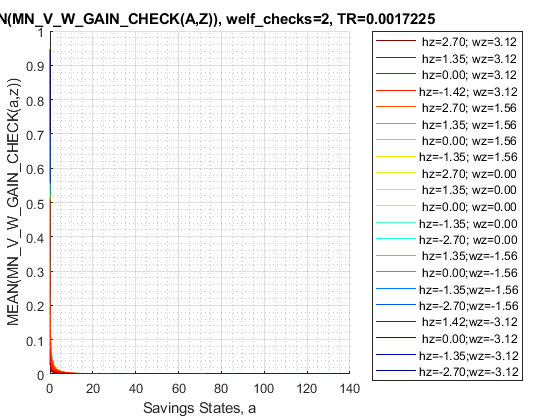

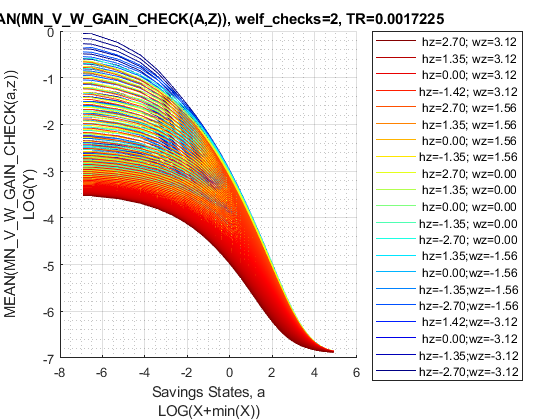

Graph Mean Consumption (*MPC: Share of Check Consumed*):

```
st_title = ['MEAN(MN\_MPC\_W\_GAIN\_CHECK(A,Z)), welf\_checks=' num2str(welf_checks) ', TR=' num2str(mp_params('TR')) ''];
mp_support_graph('cl_st_graph_title') = {st_title};
mp_support_graph('cl_st_ytitle') = {'MEAN(MN\_MPC\_W\_GAIN\_CHECK(a,z))'};
ff_graph_grid((tb_az_c{1:end, 3:end})', ar_st_eta_HS_grid, agrid, mp_support_graph);
```

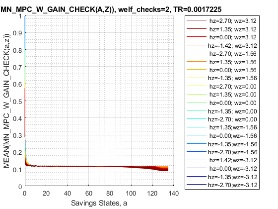

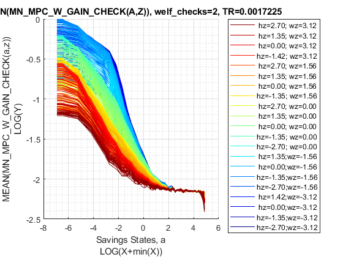

## 1.4 Analyze Kids and Marriage and Age

Aggregating over education, savings, and shocks, what are the differential effects of Marriage and Age.

```
% Generate some Data
mp_support_graph = containers.Map('KeyType', 'char', 'ValueType', 'any');
ar_row_grid = [...
    "k0M0", "K1M0", "K2M0", "K3M0", "K4M0", ...
    "k0M1", "K1M1", "K2M1", "K3M1", "K4M1"];
mp_support_graph('cl_st_xtitle') = {'Age'};
mp_support_graph('st_legend_loc') = 'best';
mp_support_graph('bl_graph_logy') = true; % do not log
mp_support_graph('st_rounding') = '6.2f'; % format shock legend
mp_support_graph('cl_scatter_shapes') = {...
    'o', 'd' ,'s', 'x', '*', ...
    'o', 'd', 's', 'x', '*'};
mp_support_graph('cl_colors') = {...
    'red', 'red', 'red', 'red', 'red'...
    'blue', 'blue', 'blue', 'blue', 'blue'};
```

MEAN(VAL(KM,J)), MEAN(AP(KM,J)), MEAN(C(KM,J))

Tabulate value and policies:

```
% Set
% NaN(n_jgrid,n_agrid,n_etagrid,n_educgrid,n_marriedgrid,n_kidsgrid);
ar_permute = [2,3,4,1,6,5];
% Value Function
st_title = ['MEAN(MN_V_W_GAIN_CHECK(KM,J)), welf_checks=' num2str(welf_checks) ', TR=' num2str(mp_params('TR'))];
tb_az_v = ff_summ_nd_array(st_title, mn_V_W_gain_check, true, ["mean"], 3, 1, cl_mp_datasetdesc, ar_permute);

xxx  MEAN(MN_V_W_GAIN_CHECK(KM,J)), welf_checks=2, TR=0.0017225  xxxxxxxxxxxxxxxxxxxxxxxxxxx
    group    kids    marry    mean_age_18    mean_age_19    mean_age_20    mean_age_21    mean_age_22    mean_age_23    mean_age_24    mean_age_25    mean_age_26    mean_age_27    mean_age_28    mean_age_29    mean_age_30    mean_age_31    mean_age_32    mean_age_33    mean_age_34    mean_age_35    …
    _____    ____    _____    ___________    ___________    ___________    ___________    ___________    ___________    ___________    ___________    ___________    ___________    ___________    ___________    ___________    ___________    ___________    ___________    ___________    ___________    …

      1       1        0       0.028443        0.027382        0.02607       0.023829       0.021959       0.020387       0.019055       0.017921       0.016951       0.016116       0.015395       0.014771       0.014231       0.013761       0.013353       0.012998       0.012691       0.012424     …
      2       2        0       0.039131        0.037712       0.035894       0.032743       0.030106        0.02788       0.025987       0.024368       0.022973       0.021767       0.020718       0.019804       0.019005       0.018305        0.01769       0.017149       0.016674       0.016256     …
      3       3        0        0.04572         0.04432        0.04241       0.038719       0.035631       0.033028       0.030815       0.028923       0.027294       0.025885        0.02466       0.023592       0.022657       0.021837       0.021116       0.020481       0.019921       0.019428     …
      4       4        0       0.051937        0.050449       0.048354       0.044164       0.040661       0.037707       0.035198       0.033051       0.031204       0.029606       0.028217       0.027005       0.025944       0.025013       0.024194       0.023473       0.022836       0.022275     …
      5       5        0       0.056986          0.0555       0.053326        0.04875       0.044927       0.041707       0.038973       0.036637       0.034629       0.032893       0.031385       0.030071       0.028921       0.027914       0.027028       0.026248       0.025561       0.024956     …
      6       1        1       0.008385       0.0079795      0.0075874      0.0068616      0.0062549      0.0057423      0.0053057      0.0049335      0.0046158      0.0043426      0.0041076      0.0039056      0.0037318      0.0035826       0.003455      0.0033459      0.0032531      0.0031745     …
      7       2        1       0.011253        0.010708       0.010181      0.0092041      0.0083817      0.0076884      0.0071024      0.0066021      0.0061711      0.0057989      0.0054773         0.0052      0.0049603      0.0047522       0.004572      0.0044165       0.004283      0.0041687     …
      8       3        1       0.013554        0.012928       0.012313       0.011136       0.010147      0.0093138      0.0086036      0.0079968      0.0074781      0.0070338       0.006651      0.0063192      0.0060309      0.0057803      0.0055632      0.0053758      0.0052148       0.005077     …
      9       4        1       0.016251        0.015529       0.014803       0.013404       0.012225       0.011226       0.010378      0.0096528      0.0090303      0.0084925       0.008027      0.0076245      0.0072769      0.0069765      0.0067162      0.0064903      0.0062949      0.0061263     …
     10       5        1       0.019768        0.018969       0.018139       0.016444       0.015026       0.013822       0.012804       0.011935       0.011191        0.01055      0.0099936        0.00951      0.0090894      0.0087252      0.0084098      0.0081364      0.0079002      0.0076963     …

% Consumption Function
st_title = ['MEAN(MN_MPC_W_GAIN_CHECK(KM,J)), welf_checks=' num2str(welf_checks) ', TR=' num2str(mp_params('TR'))];
tb_az_c = ff_summ_nd_array(st_title, mn_MPC_W_gain_share_check, true, ["mean"], 3, 1, cl_mp_datasetdesc, ar_permute);

```

[output cut: 14 more lines]

Graph Mean Values:

```
st_title = ['MEAN(MN\_V\_W\_GAIN\_CHECK(KM,J)), welf\_checks=' num2str(welf_checks) ', TR=' num2str(mp_params('TR')) ''];
mp_support_graph('cl_st_graph_title') = {st_title};
mp_support_graph('cl_st_ytitle') = {'MEAN(MN\_V\_W\_GAIN\_CHECK(KM,J))'};
ff_graph_grid((tb_az_v{1:end, 4:end}), ar_row_grid, age_grid, mp_support_graph);
```

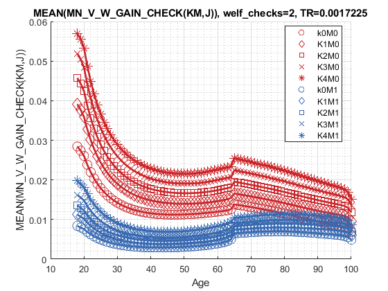

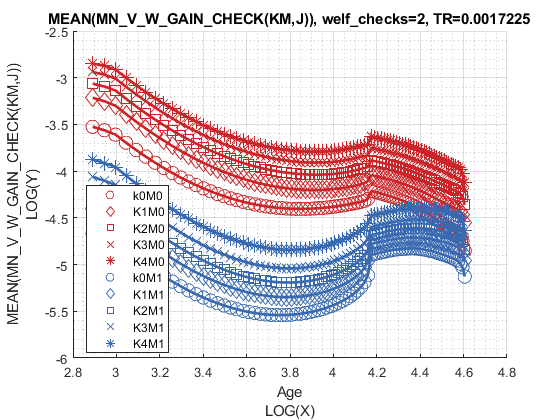

Graph Mean Consumption (*MPC: Share of Check Consumed*):

```
st_title = ['MEAN(MN\_MPC\_W\_GAIN\_CHECK(KM,J)), welf\_checks=' num2str(welf_checks) ', TR=' num2str(mp_params('TR')) ''];
mp_support_graph('cl_st_graph_title') = {st_title};
mp_support_graph('cl_st_ytitle') = {'MEAN(MN\_MPC\_W\_GAIN\_CHECK(KM,J))'};
ff_graph_grid((tb_az_c{1:end, 4:end}), ar_row_grid, age_grid, mp_support_graph);
```

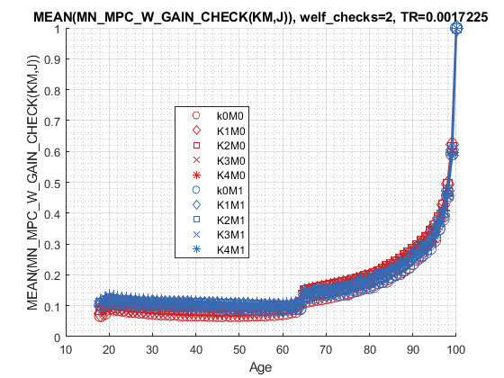

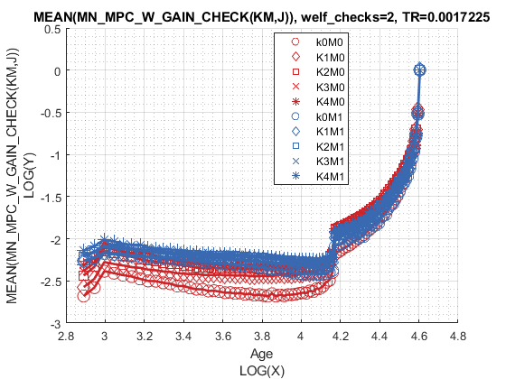

## 1.5 Analyze Education and Marriage

```
% Generate some Data
mp_support_graph = containers.Map('KeyType', 'char', 'ValueType', 'any');
ar_row_grid = ["E0M0", "E1M0", "E0M1", "E1M1"];
mp_support_graph('cl_st_xtitle') = {'Age'};
mp_support_graph('st_legend_loc') = 'best';
mp_support_graph('bl_graph_logy') = true; % do not log
mp_support_graph('st_rounding') = '6.2f'; % format shock legend
mp_support_graph('cl_scatter_shapes') = {'*', 'p', '*','p' };
mp_support_graph('cl_colors') = {'red', 'red', 'blue', 'blue'};
```

MEAN(VAL(EM,J)), MEAN(AP(EM,J)), MEAN(C(EM,J))

Tabulate value and policies:

```
% Set
% NaN(n_jgrid,n_agrid,n_etagrid,n_educgrid,n_marriedgrid,n_kidsgrid);
ar_permute = [2,3,6,1,4,5];
% Value Function
st_title = ['MEAN(MN_V_W_GAIN_CHECK(EM,J)), welf_checks=' num2str(welf_checks) ', TR=' num2str(mp_params('TR'))];
tb_az_v = ff_summ_nd_array(st_title, mn_V_W_gain_check, true, ["mean"], 3, 1, cl_mp_datasetdesc, ar_permute);

xxx  MEAN(MN_V_W_GAIN_CHECK(EM,J)), welf_checks=2, TR=0.0017225  xxxxxxxxxxxxxxxxxxxxxxxxxxx
    group    edu    marry    mean_age_18    mean_age_19    mean_age_20    mean_age_21    mean_age_22    mean_age_23    mean_age_24    mean_age_25    mean_age_26    mean_age_27    mean_age_28    mean_age_29    mean_age_30    mean_age_31    mean_age_32    mean_age_33    mean_age_34    mean_age_35    m…
    _____    ___    _____    ___________    ___________    ___________    ___________    ___________    ___________    ___________    ___________    ___________    ___________    ___________    ___________    ___________    ___________    ___________    ___________    ___________    ___________    _…

      1       0       0       0.045692       0.044619       0.043207       0.040746        0.03856       0.036612        0.034872       0.033313       0.031915       0.030657       0.029524       0.028503       0.027582        0.02675       0.025998       0.025318       0.024704        0.02415      …
      2       1       0       0.043194       0.041526       0.039215       0.034536       0.030754       0.027671         0.02514       0.023047       0.021306       0.019849       0.018626       0.017594       0.016722       0.015982       0.015354       0.014821       0.014369       0.013986      …
      3       0       1       0.014697       0.014079        0.01347       0.012491        0.01163       0.010875        0.010216      0.0096353      0.0091229      0.0086686      0.0082659      0.0079108      0.0075974      0.0073213      0.0070782      0.0068646      0.0066774      0.0065139      …
      4       1       1       0.012987       0.012367       0.011739       0.010329       0.009184       0.008242       0.0074615      0.0068127      0.0062716      0.0058186      0.0054366      0.0051129      0.0048383      0.0046054      0.0044082      0.0042414       0.004101      0.0039832      …

% Consumption
st_title = ['MEAN(MN_MPC_W_GAIN_CHECK(EM,J)), welf_checks=' num2str(welf_checks) ', TR=' num2str(mp_params('TR'))];
tb_az_c = ff_summ_nd_array(st_title, mn_MPC_W_gain_share_check, true, ["mean"], 3, 1, cl_mp_datasetdesc, ar_permute);

xxx  MEAN(MN_MPC_W_GAIN_CHECK(EM,J)), welf_checks=2, TR=0.0017225  xxxxxxxxxxxxxxxxxxxxxxxxxxx
    group    edu    marry    mean_age_18    mean_age_19    mean_age_20    mean_age_21    mean_age_22    mean_age_23    mean_age_24    mean_age_25    mean_age_26    mean_age_27    mean_age_28    mean_age_29    mean_age_30    mean_age_31    mean_age_32    mean_age_33    mean_age_34    mean_age_35    m…
    _____    ___    _____    ___________    ___________    ___________    ___________    ___________    ___________    ___________    ___________    ___________    ___________    ___________    ___________    ___________    ___________    ___________    ___________    ___________    ___________    _…

      1       0       0       0.075296       0.080407       0.092505       0.091671       0.091522       0.091354       0.090868       0.090313       0.090383       0.089653        0.09044        0.08986       0.090047       0.089487       0.089274       0.089787       0.089295       0.089199       …
      2       1       0       0.092377        0.10397        0.13038        0.12556        0.12042        0.11648        0.11242        0.10899        0.10619        0.10356        0.10114       0.098941       0.097086       0.095344       0.093827        0.09238       0.092374       0.091003       …
      3       0       1       0.099842        0.10362        0.10816        0.10847        0.10824        0.10764        0.10759        0.10778        0.10809        0.10812        0.10798        0.10769        0.10772        0.10774         0.1075        0.10722        0.10687        0.10673       …
      4       1       1        0.11684        0.12315        0.13408        0.13033        0.12767        0.12562        0.12351        0.12023        0.11798        0.11639         0.1153        0.11386        0.11284        0.11153        0.11072        0.10967        0.10909        0.10841       …
```

Graph Mean Values:

```
st_title = ['MEAN(MN\_V\_W\_GAIN\_CHECK(EM,J)), welf\_checks=' num2str(welf_checks) ', TR=' num2str(mp_params('TR')) ''];
mp_support_graph('cl_st_graph_title') = {st_title};
mp_support_graph('cl_st_ytitle') = {'MEAN(MN\_V\_W\_GAIN\_CHECK(EM,J))'};
ff_graph_grid((tb_az_v{1:end, 4:end}), ar_row_grid, age_grid, mp_support_graph);
```

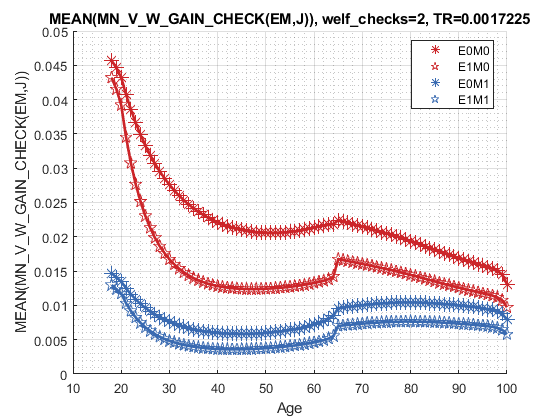

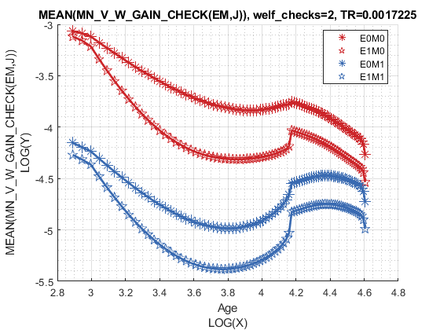

Graph Mean Consumption (*MPC: Share of Check Consumed*):

```
st_title = ['MEAN(MN\_MPC\_W\_GAIN\_CHECK(EM,J)), welf\_checks=' num2str(welf_checks) ', TR=' num2str(mp_params('TR')) ''];
mp_support_graph('cl_st_graph_title') = {st_title};
mp_support_graph('cl_st_ytitle') = {'MEAN(MN\_MPC\_W\_GAIN\_CHECK(EM,J))'};
ff_graph_grid((tb_az_c{1:end, 4:end}), ar_row_grid, age_grid, mp_support_graph);
```

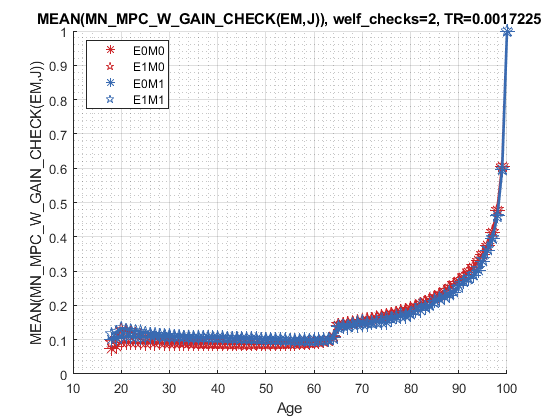

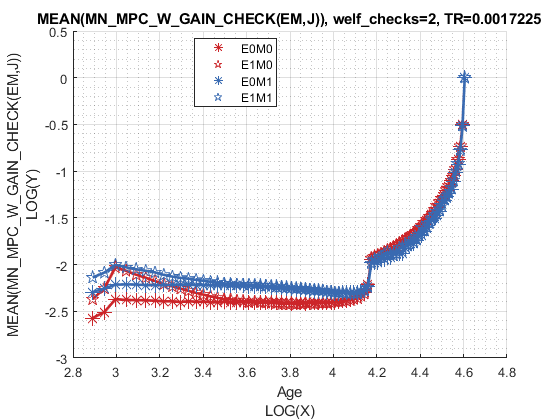